# Pegasus Pseudobulk Analysis

Author: [Bo Li](https://github.com/bli25), [Yiming Yang](https://github.com/yihming)  
Date: 2022-04-10  
Notebook Source: pseudobulk.ipynb

```python
import pegasus as pg
import pandas as pd
```

## Dataset

In this tutorial, we'll use a gene-count matrix dataset on human bone marrow from 8 donors, create pseudobulk matrix regarding donors, and perform pseudobulk analysis on the data.

The dataset is stored at https://storage.googleapis.com/terra-featured-workspaces/Cumulus/MantonBM_nonmix_subset.zarr.zip. You can also use gsutil to download it via its Google bucket URL (gs://terra-featured-workspaces/Cumulus/MantonBM_nonmix_subset.zarr.zip).

Now load the count matrix:

```python
data = pg.read_input('MantonBM_nonmix_subset.zarr.zip')
```

```
2022-04-10 21:52:30,898 - pegasusio.readwrite - INFO - zarr file 'MantonBM_nonmix_subset.zarr.zip' is loaded.
2022-04-10 21:52:30,899 - pegasusio.readwrite - INFO - Function 'read_input' finished in 0.38s.
```

## Generate pseudobulk matrix

Pegasus provides `pseudobulk` function to generate pseudobulk matrix. The code below generate a pseudobulk count matrix regarding donors (`Channel`), and transfer the gender attribute to the resulting pseudobulks:

```python
pseudo = pg.pseudobulk(data, 'Channel', 'gender')
pseudo
```

```
2022-04-10 21:52:31,157 - pegasus.tools.pseudobulk - INFO - Function 'pseudobulk' finished in 0.25s.
```

```
UnimodalData object with n_obs x n_vars = 8 x 36601
    Genome: Channel; Modality: pseudobulk
    It contains 1 matrix: 'X'
    It currently binds to matrix 'X' as X

    obs: 'gender'
    var: 'featureid'
    uns: 'genome', 'modality'
```

For details on `pseudobulk` function, please see its [documentation](https://pegasus.readthedocs.io/en/stable/api/pegasus.pseudobulk.html).

## Differential Expression (DE) Analysis on Pseudobulk Matrix

Pegasus has `deseq2` function to perform DE analysis on Pseudobulk data, which is a Python wrapper of [DESeq2](https://bioconductor.org/packages/release/bioc/html/DESeq2.html) package in R (You need to first install the original R package). The code below analyzes based on a regression model considering the gender attribute, and estimates the contrast between `female` and `male`:

```python
pg.deseq2(pseudo, '~gender', ('gender', 'female', 'male'))
```

```
R[write to console]: estimating size factors

R[write to console]: estimating dispersions

R[write to console]: gene-wise dispersion estimates

R[write to console]: mean-dispersion relationship

R[write to console]: final dispersion estimates

R[write to console]: fitting model and testing
```

```
2022-04-10 21:52:47,487 - pegasus.tools.pseudobulk - INFO - Function 'deseq2' finished in 16.32s.
```

```python
pd.DataFrame(pseudo.varm["deseq2"], index=pseudo.var_names)
```

| featurekey | baseMean | log2FoldChange | lfcSE | stat | pvalue | padj |
| --- | --- | --- | --- | --- | --- | --- |
| MIR1302-2HG | 0.113807 | 0.696538 | 3.533812 | 0.197107 | 0.843744 | 1.00000 |
| FAM138A | 0.000000 | 0.000000 | 0.000000 | 0.000000 | 1.000000 | 1.00000 |
| OR4F5 | 0.000000 | 0.000000 | 0.000000 | 0.000000 | 1.000000 | 1.00000 |
| AL627309.1 | 3.131268 | 0.239777 | 0.913821 | 0.262389 | 0.793022 | 0.99985 |
| AL627309.3 | 0.000000 | 0.000000 | 0.000000 | 0.000000 | 1.000000 | 1.00000 |
| ... | ... | ... | ... | ... | ... | ... |
| AC141272.1 | 0.113807 | 0.696538 | 3.533812 | 0.197107 | 0.843744 | 1.00000 |
| AC023491.2 | 0.000000 | 0.000000 | 0.000000 | 0.000000 | 1.000000 | 1.00000 |
| AC007325.1 | 0.000000 | 0.000000 | 0.000000 | 0.000000 | 1.000000 | 1.00000 |
| AC007325.4 | 68.286678 | -0.911313 | 0.724284 | -1.258226 | 0.208310 | 0.99985 |
| AC007325.2 | 0.121696 | -0.746135 | 3.533812 | -0.211142 | 0.832777 | 1.00000 |

36601 rows × 6 columns

Notice that the fold-change calculated has `female` be the numerator, while `male` be the denominator.

For details on `deseq2` function, please see its [documentation](https://pegasus.readthedocs.io/en/stable/api/pegasus.deseq2.html).

### Get significant DE genes in human-readable format

```python
markers = pg.pseudo.markers(pseudo)
print(markers)
```

```
{'up':                baseMean  log2FoldChange     lfcSE       stat        pvalue  \
featurekey
XIST        1910.572444       13.615371  1.043313  13.050131  6.343849e-39
PPP1R2C       14.765863        7.317893  1.165723   6.277559  3.439292e-10
LINC00221      9.121555        5.188543  1.230549   4.216444  2.481844e-05
TSIX          13.654597        3.889226  0.725102   5.363692  8.153793e-08
KANTR         88.919116        1.248766  0.289454   4.314216  1.601703e-05
BX890604.2   297.379563        1.233275  0.260909   4.726846  2.280338e-06
JPX         1129.585486        0.888090  0.198601   4.471729  7.758989e-06

                    padj
featurekey
XIST        5.397347e-35
PPP1R2C     3.657687e-07
LINC00221   1.759627e-02
TSIX        7.708052e-05
KANTR       1.184982e-02
BX890604.2  1.940112e-03
JPX         6.001225e-03  , 'down':                baseMean  log2FoldChange     lfcSE       stat        pvalue  \
featurekey
RPS4Y1      6547.060706      -16.138498  1.050588 -15.361401  2.970823e-53
EIF1AY      1316.973725      -13.825299  1.087960 -12.707548  5.369171e-37
DDX3Y        451.442937      -12.280059  1.083214 -11.336691  8.634834e-30
UTY          195.114474      -11.068404  1.074641 -10.299634  7.073023e-25
PRKY         152.182688      -10.709941  1.084543  -9.875073  5.339433e-23
KDM5D        132.117709      -10.504537  1.069489  -9.822019  9.051192e-23
USP9Y        208.307283      -10.440421  1.086045  -9.613253  7.029269e-22
ZFY           87.153393       -9.905218  1.071056  -9.248081  2.285583e-20
AC244213.1    67.131335       -9.527208  1.097804  -8.678421  4.013006e-18
TTTY14        61.185802       -9.402545  1.084608  -8.669075  4.356434e-18
TMSB4Y        39.206868       -8.755393  1.075498  -8.140781  3.927369e-16
LINC00278     27.826253       -8.258319  1.099821  -7.508787  5.967764e-14
AC006157.1    19.899699       -7.768185  1.090473  -7.123686  1.050784e-12
TTTY10        12.079865       -6.316182  1.116495  -5.657152  1.539057e-08
AC010889.1     5.644311       -5.964417  1.227109  -4.860542  1.170648e-06
SCGB3A1      110.430089       -3.424882  0.544527  -6.289648  3.181862e-10
TPSB2         63.396259       -2.604417  0.560631  -4.645512  3.392345e-06

                    padj
featurekey
RPS4Y1      5.055152e-49
EIF1AY      3.045394e-33
DDX3Y       3.673258e-26
UTY         2.407091e-21
PRKY        1.514263e-19
KDM5D       2.200215e-19
USP9Y       1.495125e-18
ZFY         4.321275e-17
AC244213.1  6.739007e-15
TTTY14      6.739007e-15
TMSB4Y      5.569009e-13
LINC00278   7.811343e-11
AC006157.1  1.277153e-09
TTTY10      1.540506e-05
AC010889.1  1.048408e-03
SCGB3A1     3.609505e-07
TPSB2       2.748769e-03  }
```

### Write DE results to spreadsheet

```python
pg.pseudo.write_results_to_excel(markers, 'test.de.xlsx')
```

```
2022-04-10 21:52:47,568 - pegasus.pseudo.convenient - INFO - Excel spreadsheet is written.
2022-04-10 21:52:47,569 - pegasus.pseudo.convenient - INFO - Function 'write_results_to_excel' finished in 0.04s.
```

### Generate volcano plot

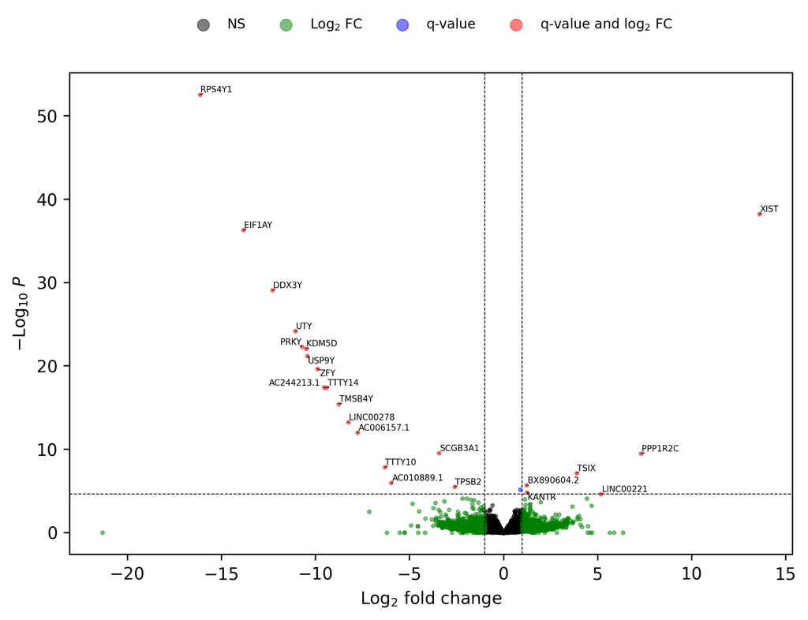

```python
pg.pseudo.volcano(pseudo)
```

## Gene Set Enrichment Analysis (GSEA)

Pegasus has `fgsea` function to perform GSEA analysis, which is a Python wrapper of [fgsea](http://bioconductor.org/packages/release/bioc/html/fgsea.html) package in R (You need to first install the original R package):

```python
pg.fgsea(pseudo, 'log2FoldChange', 'canonical_pathways', 'deseq2', fgsea_key = 'fgsea_deseq2')
```

```
2022-04-10 21:52:49,623 - pegasus.tools.utils - INFO - Loaded signatures from GMT file /home/yiming/GitHub/pegasus/pegasus/data_files/c2.cp.v7.5.1.symbols.gmt.
2022-04-10 21:52:53,051 - pegasus.tools.fgsea - INFO - Function 'fgsea' finished in 3.63s.
```

The code above runs GSEA analysis based on log2 fold-change values, and use one of the preset gene sets that Pegasus provides:

- `canonical_pathways`: The [MsigDB](http://www.gsea-msigdb.org/gsea/msigdb/collections.jsp) C2/CP gene set.
- `hallmark`: The [MsigDB](http://www.gsea-msigdb.org/gsea/msigdb/collections.jsp) H gene set. Notice that this function is applicable to DE results from both single-cell and pseudobulk data.

For details on `fgsea` function, please see its [documentation](https://pegasus.readthedocs.io/en/stable/api/pegasus.fgsea.html).

### Generate GSEA plots

Finally, generate the GSEA histograms by `plot_gsea` function. In general, there will be 2 panels:

- Top panel shows the up-regulated pathways in red color.
- Bottom panel shows the down-regulated pathways in green color.

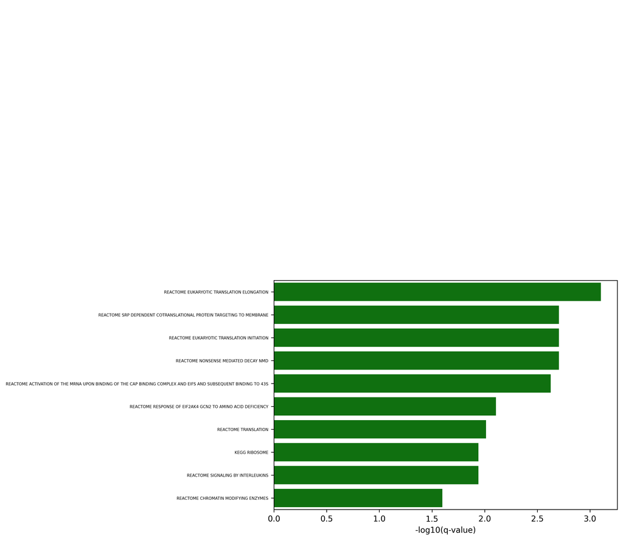

```python
pg.plot_gsea(pseudo, 'fgsea_deseq2')
```

As shown in the plot above, for this pseudobulk data, there is no up-regulated (i.e. female significant) pathways, while some down-regulated (i.e. male significant) pathways are observed.